# Time Series Analysis on e-Commerece Data to Predict the Price of a Product in FUTURE

# Problem Description

Using e-commerce data, build time series models to predict the price of a certain product 4 weeks in advance. And finally evaluate each of the algorithms.

### Clear the Global Environment

```r
rm(list=ls(all=TRUE))
```

### Load required R library

```r
library(zoo)
library(dplyr)
library(TTR)
library(forecast)
library(DMwR)
library(data.table)
```

### Read Data from RData

- Set current working directory
- Use readRDS function to read RData file

```r
# setwd("I:/DATA-SCIENCE/FACULTY/BATCH-47/CSE7302c-Statistics and Probability in Decision Modeling/TimeSeries/20180922_Batch47_CSE7302c_Time_Series_LabActivity")


data = readRDS("ecommerceData.RData")
#data = readRDS("test.RData")
```

### Explore and understand the data

```r
## Dimension of the Data set
dim(data)
```

```
## [1] 3316190       6
```

```r
## Look at the summary statistics
summary(data)
```

```
##       V1               TitleKey           Price            Quantity
##  Length:3316190     Min.   : 221205   Min.   :   0.01   Min.   :  1.00
##  Class :character   1st Qu.:1561944   1st Qu.:  63.97   1st Qu.:  1.00
##  Mode  :character   Median :4302628   Median :  86.85   Median :  1.00
##                     Mean   :4407778   Mean   :  91.82   Mean   : 30.77
##                     3rd Qu.:6989428   3rd Qu.: 113.93   3rd Qu.:  3.00
##                     Max.   :9186772   Max.   :2545.21   Max.   :999.00
##   Condition             Date
##  Length:3316190     Length:3316190
##  Class :character   Class :character
##  Mode  :character   Mode  :character
##
##
##
```

```r
## As it is not very clearn, lets look at the first and last 10 records using head and tail commands
head(data, 10)
```

```
##     V1 TitleKey  Price Quantity Condition       Date
##  1:  1  8374241  73.40        1       New 2009-06-01
##  2:  2  6252362 108.00        1 Very Good 2009-06-01
##  3:  3  8049481 111.02        1      Mint 2009-06-01
##  4:  4  6399602 127.80        1      Mint 2009-06-01
##  5:  5  1091846 118.00        1       New 2009-06-01
##  6:  6  1198056  44.90        1      Mint 2009-06-01
##  7:  7  1532705  84.15        4       New 2009-06-01
##  8:  8  1118812  82.89       41       New 2009-06-01
##  9:  9  1123511  71.80        2      Good 2009-06-01
## 10: 10  4690721  50.00        1      Good 2009-06-01
```

```r
tail(data, 10)
```

```
##          V1 TitleKey  Price Quantity  Condition       Date
##  1: 3316181  2873279  49.95        1       Good 2013-08-09
##  2: 3316182  2231521  48.98        1        New 2013-08-09
##  3: 3316183  1018776  50.00        1       Mint 2013-08-09
##  4: 3316184  8977907 114.42        1 Acceptable 2013-08-09
##  5: 3316185   490823 105.95        1        New 2013-08-09
##  6: 3316186  8768865  63.91        1       Mint 2013-08-09
##  7: 3316187  2808755 112.86        1       Good 2013-08-09
##  8: 3316188  3120432 149.95        1 Acceptable 2013-08-09
##  9: 3316189  1462143 149.76        4        New 2013-08-09
## 10: 3316190  6399602  60.00        1       Good 2013-08-09
```

```r
## Look into Condition attribute
table(data$Condition)
```

```
##
## Acceptable       Good       Mint        New  Very Good
##     284251     778239     280389    1593241     380070
```

```r
## Look into Titlekey attribute
table(data$TitleKey)
```

```
##
##  221205  273693  315169  367034  432113  433756  490823  506270  842501
##   32051   31991   32866   32574   32699   31663   32820   32597   32561
##  879967 1018776 1091846 1118812 1123511 1138845 1140553 1198056 1205266
##   32724   33243   32307   32454   32217   30684   32359   33702   32870
## 1288607 1462143 1464896 1515222 1523071 1532705 1541863 1561944 1619727
##   31814   31199   32598   32661   33088   32136   33188   31879   32614
## 1644625 1707665 1752438 2096577 2231521 2422979 2437264 2443602 2446225
##   20176   32729   32794   31656   32727   32698   26246   32420   32333
## 2450811 2451420 2660657 2773679 2808755 2871259 2873279 3019001 3119793
##   33052   32394   34068   29268   32905   32422   32431   32318   32415
## 3120432 3121347 3128336 3128938 4283861 4289323 4302628 4389202 4456969
##   32534   33361   32565   31071   33981   32555   33807   32563   31470
## 4505684 4511602 4676989 4687744 4688228 4690721 4702308 4705669 4730066
##   32194   32530   31951   32336   32509   32344   32884   32940   32566
## 4735628 4770054 4793422 4862728 5124701 5294728 5724329 6252362 6254632
##   26243   32601   32161   16454   32260   32343   29561   31273   32672
## 6399602 6485311 6760671 6871280 6896787 6915669 6989428 8044330 8045088
##   31525   29305   28499   30498   32065   31715   29433   31558   31633
## 8046315 8046648 8046762 8048046 8049481 8050017 8366789 8374241 8768865
##   29719   29578   30837   30827   31212   30522   29475   33082   28739
## 8772755 8778959 8787038 8799748 8830516 8896060 8944101 8946697 8973539
##   32956   28705   27884   30325   28957   26103   28412   25816   28363
## 8977907 9000092 9010840 9062282 9078964 9117389 9149582 9186772
##   27366   27926   28191   26821   27455   26095   25606   26647
```

```r
## Find out number of the TitleKeys
length(unique(data$TitleKey))
```

```
## [1] 107
```

```r
## Confirm whether V1 is unique for each of the record
length(unique(data$V1))
```

```
## [1] 3316190
```

### Drop V1 unnecessary attribute and convert remaining attributes into appropriate type

```r
data$V1 = NULL

data$TitleKey = as.factor(data$TitleKey)
data$Price = as.numeric(data$Price)
data$Quantity = as.numeric(data$Quantity)
data$Condition = as.factor(data$Condition)
data$Date = as.Date(data$Date, format="%Y-%m-%d")
```

```r
# Summary of the data
summary(data)
```

```
##     TitleKey           Price            Quantity           Condition
##  2660657:  34068   Min.   :   0.01   Min.   :  1.00   Acceptable: 284251
##  4283861:  33981   1st Qu.:  63.97   1st Qu.:  1.00   Good      : 778239
##  4302628:  33807   Median :  86.85   Median :  1.00   Mint      : 280389
##  1198056:  33702   Mean   :  91.82   Mean   : 30.77   New       :1593241
##  3121347:  33361   3rd Qu.: 113.93   3rd Qu.:  3.00   Very Good : 380070
##  1018776:  33243   Max.   :2545.21   Max.   :999.00
##  (Other):3114028
##       Date
##  Min.   :2009-01-01
##  1st Qu.:2010-06-14
##  Median :2011-08-31
##  Mean   :2011-08-17
##  3rd Qu.:2012-10-23
##  Max.   :2013-12-02
##
```

```r
# Re-look at the first 6 records
head(data)
```

```
##    TitleKey  Price Quantity Condition       Date
## 1:  8374241  73.40        1       New 2009-06-01
## 2:  6252362 108.00        1 Very Good 2009-06-01
## 3:  8049481 111.02        1      Mint 2009-06-01
## 4:  6399602 127.80        1      Mint 2009-06-01
## 5:  1091846 118.00        1       New 2009-06-01
## 6:  1198056  44.90        1      Mint 2009-06-01
```

### Focusing on a particular product of choice

- Since different products price vary in a different way along the year we choose a particular product and the records that are in Good Condition.

```r
data = data[data$TitleKey==6989428 & data$Condition=="Good",]
```

### Basic info about that product

```r
dim(data)
```

```
## [1] 5848    5
```

```r
summary(data)
```

```
##     TitleKey        Price           Quantity           Condition
##  6989428:5848   Min.   : 39.84   Min.   : 1.000   Acceptable:   0
##  221205 :   0   1st Qu.: 60.00   1st Qu.: 1.000   Good      :5848
##  273693 :   0   Median : 72.25   Median : 1.000   Mint      :   0
##  315169 :   0   Mean   : 73.30   Mean   : 3.334   New       :   0
##  367034 :   0   3rd Qu.: 83.75   3rd Qu.: 3.000   Very Good :   0
##  432113 :   0   Max.   :999.00   Max.   :68.000
##  (Other):   0
##       Date
##  Min.   :2009-04-15
##  1st Qu.:2011-01-26
##  Median :2012-03-01
##  Mean   :2011-12-31
##  3rd Qu.:2013-01-08
##  Max.   :2013-12-02
##
```

```r
head(data)
```

```
##    TitleKey  Price Quantity Condition       Date
## 1:  6989428  84.38        1      Good 2009-12-08
## 2:  6989428 115.98        1      Good 2009-06-01
## 3:  6989428 115.98        1      Good 2009-06-02
## 4:  6989428  84.38        1      Good 2009-12-09
## 5:  6989428 115.98        1      Good 2009-06-03
## 6:  6989428  84.38        1      Good 2009-12-10
```

```r
data = data[order(data$Date, decreasing=F), ]

head(data,10)
```

```
##     TitleKey  Price Quantity Condition       Date
##  1:  6989428  58.65        1      Good 2009-04-15
##  2:  6989428  79.64        1      Good 2009-04-16
##  3:  6989428  58.65        1      Good 2009-04-16
##  4:  6989428  79.64        1      Good 2009-04-17
##  5:  6989428  58.65        1      Good 2009-04-17
##  6:  6989428  79.64        1      Good 2009-04-18
##  7:  6989428 115.98        1      Good 2009-05-30
##  8:  6989428 115.98        1      Good 2009-05-31
##  9:  6989428 115.98        1      Good 2009-06-01
## 10:  6989428 115.98        1      Good 2009-06-02
```

### Observation & Analysis

- On the given date, product has multiple prices, so one way is to consider the min price.
- Use dplyr package to do the same.

```r
data = data %>% group_by(Date) %>% summarise("MinPrice" = min(Price))

data = data.frame(data)

head(data,10)
```

```
##          Date MinPrice
## 1  2009-04-15    58.65
## 2  2009-04-16    58.65
## 3  2009-04-17    58.65
## 4  2009-04-18    79.64
## 5  2009-05-30   115.98
## 6  2009-05-31   115.98
## 7  2009-06-01   115.98
## 8  2009-06-02   115.98
## 9  2009-06-03   115.98
## 10 2009-06-04   115.98
```

### Handle missing values

- Some times there will be missing entries in dates, which will create a missing day/month/quarter/anual

### Detect missing values

- Using min and max date in the data, create new date field with continuous sequence of dates
- Check Data field in Data against newly created data field and find missing values.

```r
minDate = min(data$Date)
maxDate = max(data$Date)

seq = data.frame("DateRange"=seq(minDate, maxDate, by="days"))

data = seq %>% full_join(data, c("DateRange" = "Date"))

data = data.frame(data)

rm(minDate, maxDate, seq)

head(data)
```

```
##    DateRange MinPrice
## 1 2009-04-15    58.65
## 2 2009-04-16    58.65
## 3 2009-04-17    58.65
## 4 2009-04-18    79.64
## 5 2009-04-19       NA
## 6 2009-04-20       NA
```

### Impuation of Missing Values

- Replace the missing values by taking average of it’s preceding and succeeding values.
- For that, use na.locf function in the “zoo” package and rev function

```r
#data$MinPrice = (na.locf(data$MinPrice) +rev(na.locf(rev(data$MinPrice))))/2

data$MinPrice = (na.locf(data$MinPrice) + na.locf(data$MinPrice, fromLast = TRUE))/2

head(data)
```

```
##    DateRange MinPrice
## 1 2009-04-15    58.65
## 2 2009-04-16    58.65
## 3 2009-04-17    58.65
## 4 2009-04-18    79.64
## 5 2009-04-19    97.81
## 6 2009-04-20    97.81
```

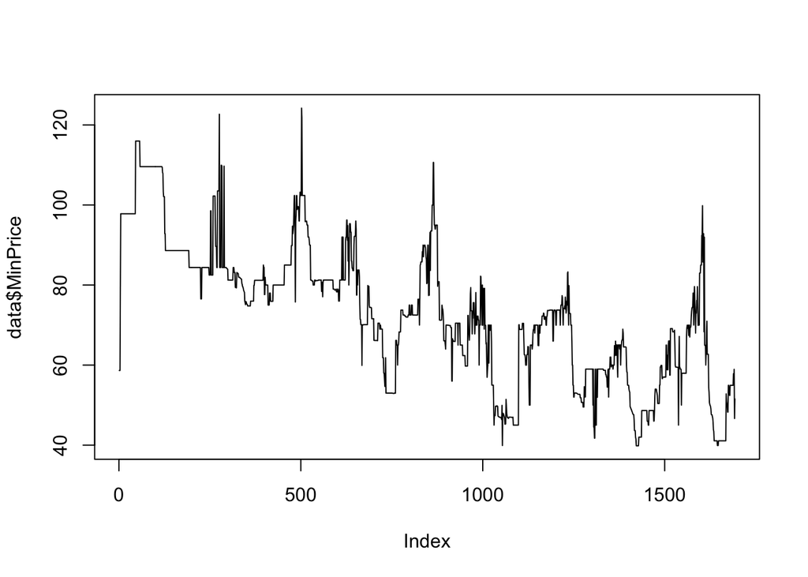

```r
plot(data$MinPrice, type = 'l')
```

### Observation on MinPrice

- In this data set price is not changing much on daily basis, so it can be aggregated to Week level or Month level

```r
# Derive Year and Month attribute
data$Year = as.numeric(format(data$DateRange, format="%Y"))
data$Year
```

```
##    [1] 2009 2009 2009 2009 2009 2009 2009 2009 2009 2009 2009 2009 2009
##   [14] 2009 2009 2009 2009 2009 2009 2009 2009 2009 2009 2009 2009 2009
##   [27] 2009 2009 2009 2009 2009 2009 2009 2009 2009 2009 2009 2009 2009
##   [40] 2009 2009 2009 2009 2009 2009 2009 2009 2009 2009 2009 2009 2009
##   [53] 2009 2009 2009 2009 2009 2009 2009 2009 2009 2009 2009 2009 2009
##   [66] 2009 2009 2009 2009 2009 2009 2009 2009 2009 2009 2009 2009 2009
##   [79] 2009 2009 2009 2009 2009 2009 2009 2009 2009 2009 2009 2009 2009
##   [92] 2009 2009 2009 2009 2009 2009 2009 2009 2009 2009 2009 2009 2009
##  [105] 2009 2009 2009 2009 2009 2009 2009 2009 2009 2009 2009 2009 2009
##  [118] 2009 2009 2009 2009 2009 2009 2009 2009 2009 2009 2009 2009 2009
##  [131] 2009 2009 2009 2009 2009 2009 2009 2009 2009 2009 2009 2009 2009
##  [144] 2009 2009 2009 2009 2009 2009 2009 2009 2009 2009 2009 2009 2009
##  [157] 2009 2009 2009 2009 2009 2009 2009 2009 2009 2009 2009 2009 2009
##  [170] 2009 2009 2009 2009 2009 2009 2009 2009 2009 2009 2009 2009 2009
##  [183] 2009 2009 2009 2009 2009 2009 2009 2009 2009 2009 2009 2009 2009
```

[output cut: 116 more lines]

```r
data$Month = as.numeric(format(data$DateRange, format="%m"))


data = data %>% group_by(Year, Month) %>% summarise("MeanPrice" = mean(MinPrice))

data = data.frame(data)
head(data)
```

```
##   Year Month MeanPrice
## 1 2009     4  89.33187
## 2 2009     5  98.98226
## 3 2009     6 111.71333
## 4 2009     7 109.58000
## 5 2009     8  99.34645
## 6 2009     9  88.61500
```

```r
# Creating sequence Time variable.
data$Time = 1:nrow(data)
data$Time
```

```
##  [1]  1  2  3  4  5  6  7  8  9 10 11 12 13 14 15 16 17 18 19 20 21 22 23
## [24] 24 25 26 27 28 29 30 31 32 33 34 35 36 37 38 39 40 41 42 43 44 45 46
## [47] 47 48 49 50 51 52 53 54 55 56 57
```

```r
data$Month = as.factor(data$Month)
data$Year = NULL

head(data)
```

```
##   Month MeanPrice Time
## 1     4  89.33187    1
## 2     5  98.98226    2
## 3     6 111.71333    3
## 4     7 109.58000    4
## 5     8  99.34645    5
## 6     9  88.61500    6
```

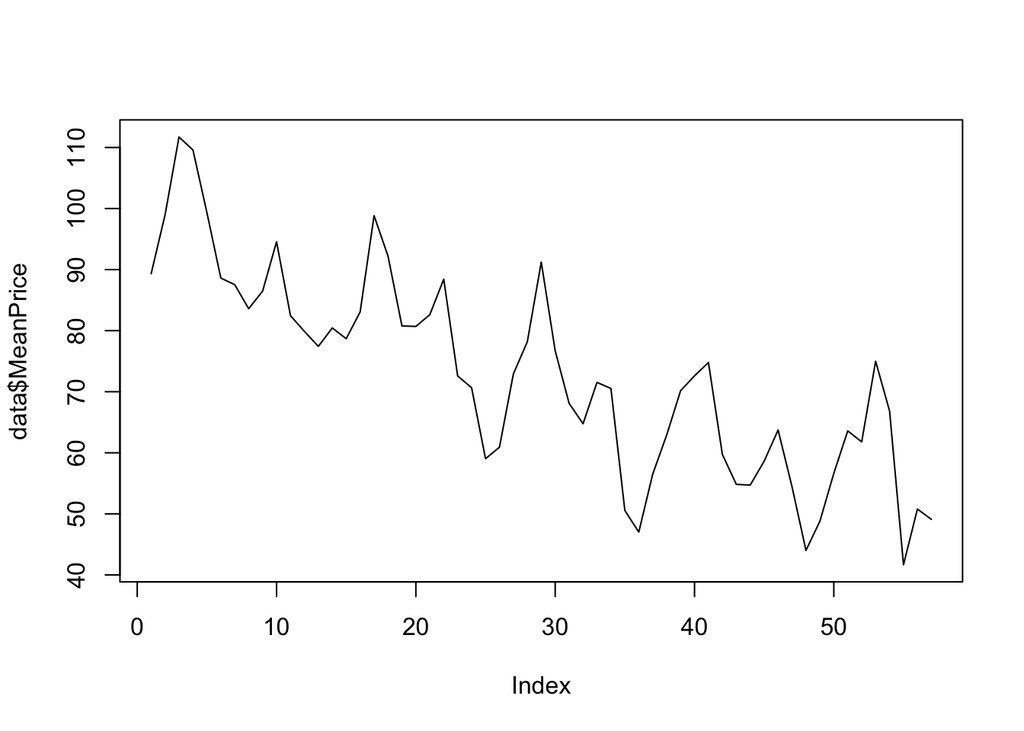

```r
plot(data$MeanPrice, type = 'l')
```

### Splitting of the Dataset into Train and Test

- As this data set is time dependent and sequence is important i.e. no random split.

```r
# View(data)
```

```r
train = data[1:45,]
test = data[46:nrow(data),]
rm(data)

head(train)
```

```
##   Month MeanPrice Time
## 1     4  89.33187    1
## 2     5  98.98226    2
## 3     6 111.71333    3
## 4     7 109.58000    4
## 5     8  99.34645    5
## 6     9  88.61500    6
```

```r
head(test)
```

```
##    Month MeanPrice Time
## 46     1  63.73032   46
## 47     2  54.42857   47
## 48     3  44.01097   48
## 49     4  48.79200   49
## 50     5  56.64129   50
## 51     6  63.58633   51
```

### Converting data into R time series object

- Our target variable is price and price is aggrigated at month level

```r
train_TS <- ts(train$MeanPrice, frequency = 12, start = c(2009, 4))
train_TS
```

```
##            Jan       Feb       Mar       Apr       May       Jun       Jul
## 2009                                89.33187  98.98226 111.71333 109.58000
## 2010  94.56161  82.45250  79.88065  77.42767  80.44161  78.68367  83.06452
## 2011  88.42161  72.58196  70.64968  59.03067  60.91677  72.91667  78.18194
## 2012  70.53839  50.55517  47.01290  56.50133  62.88645  70.15700  72.60000
##            Aug       Sep       Oct       Nov       Dec
## 2009  99.34645  88.61500  87.52210  83.59500  86.47677
## 2010  98.83145  92.20900  80.77274  80.69867  82.61000
## 2011  91.21645  76.70200  68.08935  64.75600  71.52661
## 2012  74.79161  59.73300  54.82694  54.71333  58.62968
```

```r
test_TS <- ts(test$MeanPrice, frequency = 12, start = c(2013, 1))
test_TS
```

```
##           Jan      Feb      Mar      Apr      May      Jun      Jul
## 2013 63.73032 54.42857 44.01097 48.79200 56.64129 63.58633 61.78355
##           Aug      Sep      Oct      Nov      Dec
## 2013 74.99113 66.84800 41.66387 50.78450 49.10000
```

### Vizualize the time series Data

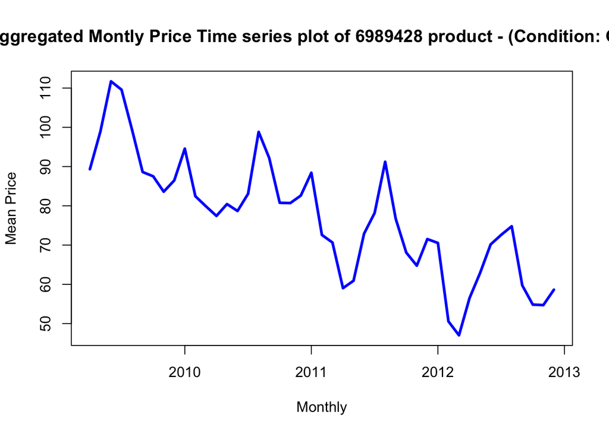

```r
plot(train_TS,
     type="l", lwd=3, col="blue",
     xlab="Monthly", ylab="Mean Price",
     main="Aggregated Montly Price Time series plot of 6989428 product - (Condition: Good)")
```

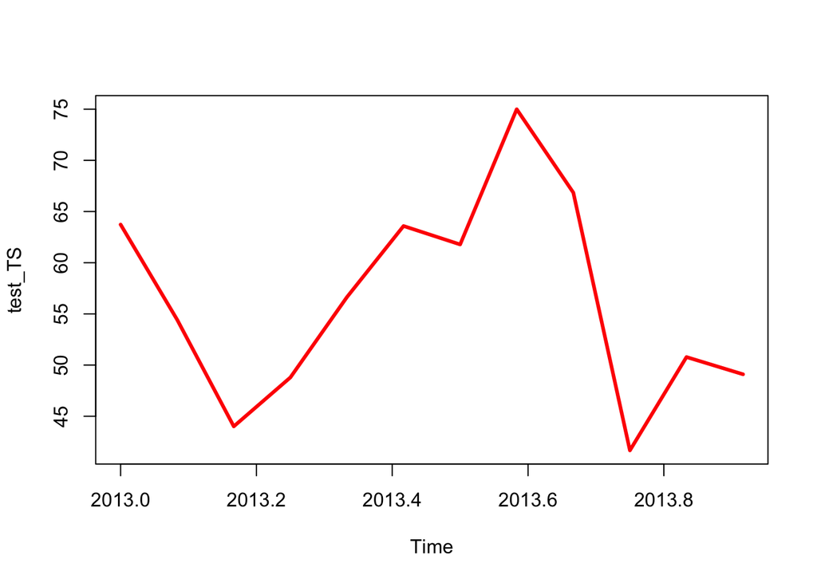

```r
plot(test_TS, col="red", lwd=3)
```

### Decomposed Time Series * Decompose will provide more information on seasonality,trend and randomness

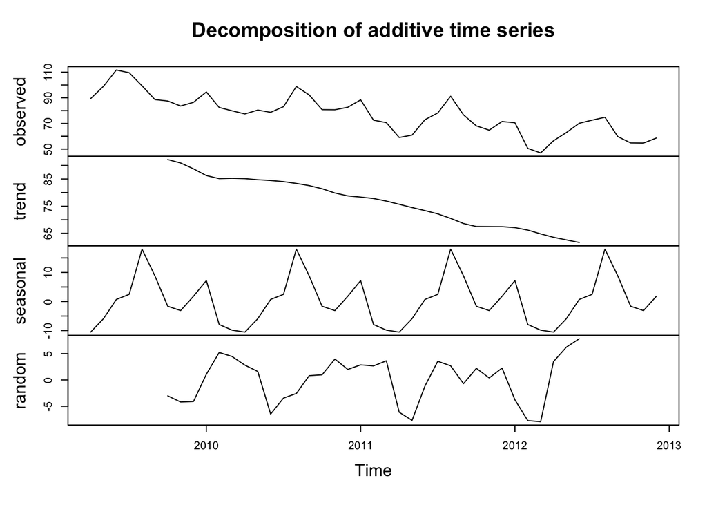

```r
train_Decomposed = decompose(train_TS)
plot(train_Decomposed)
```

```r
rm(train_Decomposed)
```

### ACF, PACF plots

- ACF: n th lag of ACF is the correlation between a day and n days before that. ??? PACF: The same as ACF with all intermediate correlations removed.

```r
par(mfrow=c(1,1))
plot(diff(train_TS, lag=1), type="l") # the lag=1 is per month lag, for seasonal lag lag will be 12
```

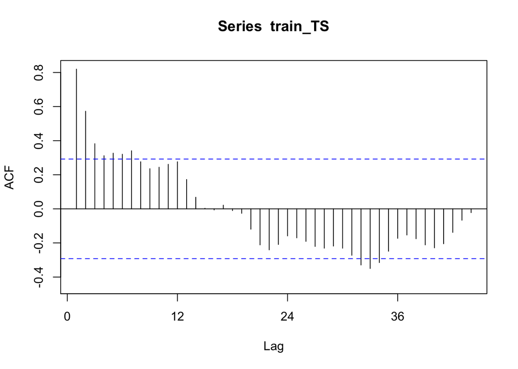

```r
Acf(train_TS,lag=44) # lag is how many datpoints to view in the plot
```

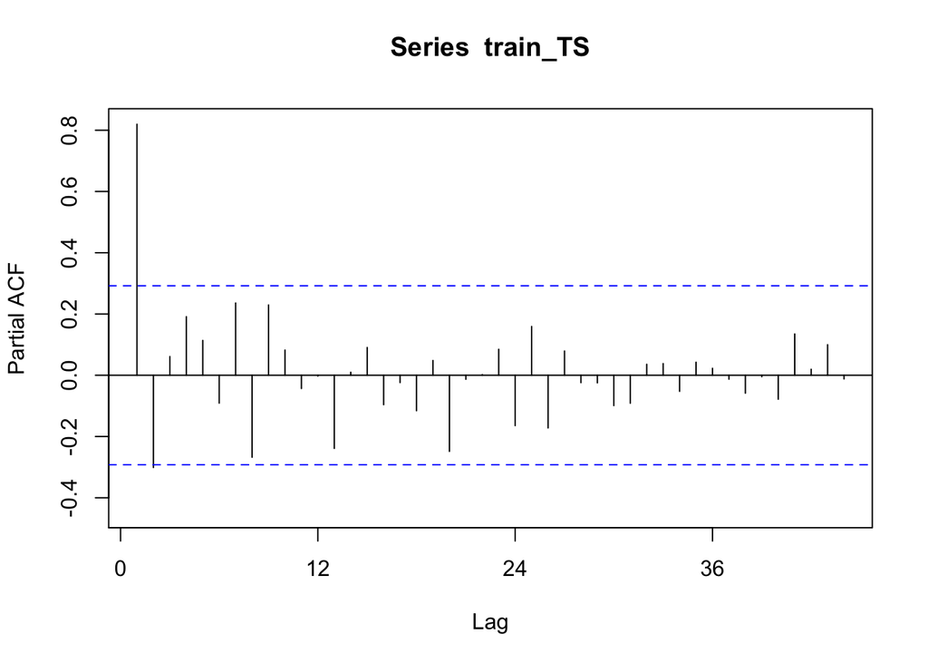

```r
Pacf(train_TS,lag=44)
```

* ACF and PACF ??? Idealized Trend, Seasonality and Randomness ??? Ideal Trend : Decreasing ACF and 1 or 2 lags of PACF ??? Ideal Seasonality: Cyclicality in ACF and a few lags of PACF with some positive and some negative ??? Ideal Random : A spike may or may not be present; even if present, magnitude will be small

- Looking at the Y scale in ACF we observe that both trend and seasonality is present.

```r
par(mfrow=c(1,1))

plot(diff(train_TS, lag=1), type="l")
```

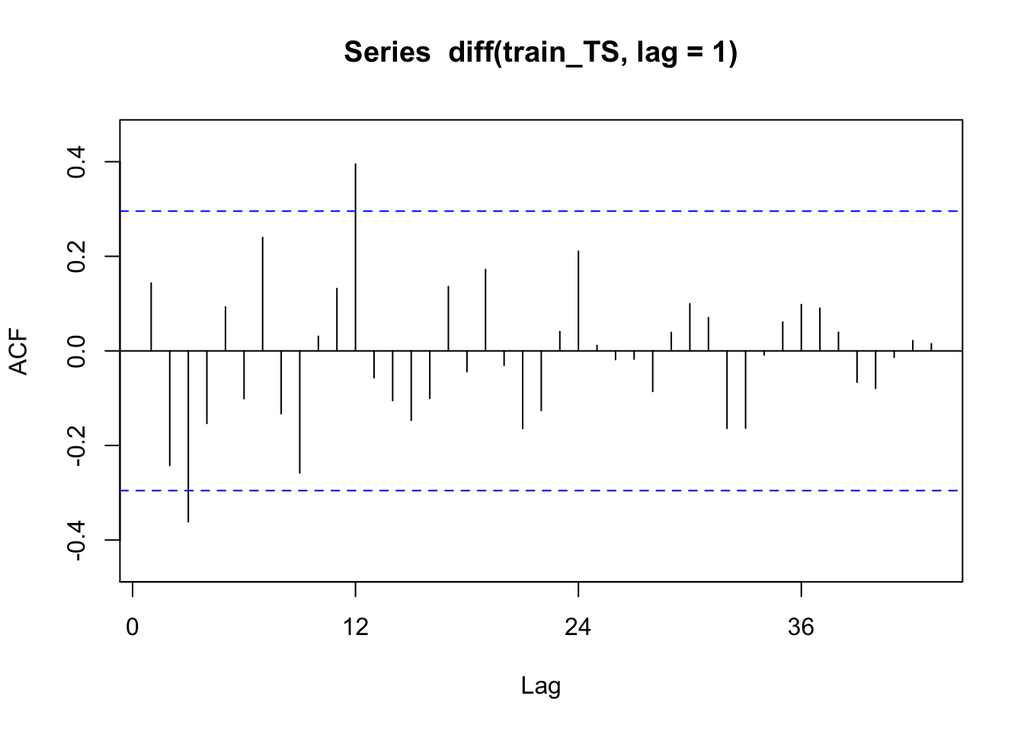

```r
Acf(diff(train_TS,lag=1), lag=43)
```

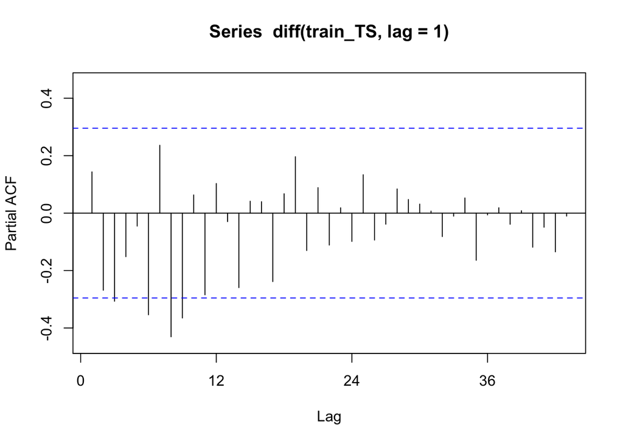

```r
Pacf(diff(train_TS, lag=1),lag=43)
```

### Stationarize by differencing * ndiffs and nsdiffs functions of forecast package can be used to findout the number of differences and seasonal differences, required to stationarize the data

```r
ndiffs(train_TS)
```

```
## [1] 1
```

```r
nsdiffs(train_TS)
```

```
## [1] 1
```

### Modelling the time series using simple moving averages

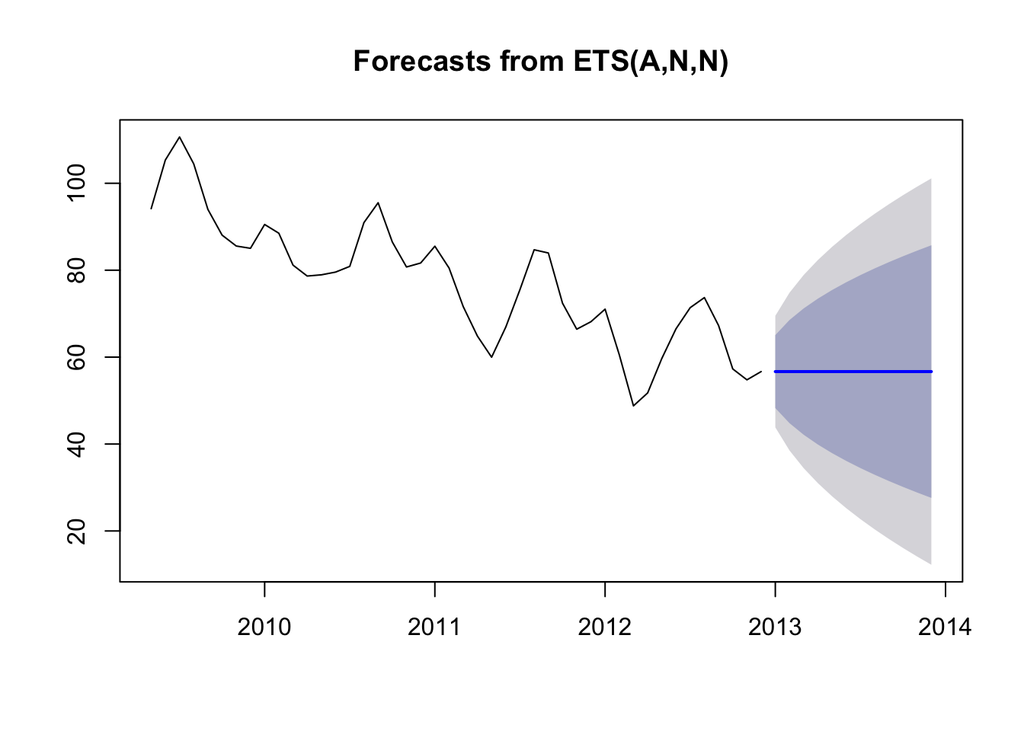

```r
fitsma = SMA(train_TS, n=2)
predsma = forecast(fitsma, h=12)
plot(predsma)
```

### Find error for SMA on both Test and Train data

```r
smaTrainError = regr.eval(train_TS[2:length(train_TS)], fitsma[2:length(train_TS)])
smaTestError = regr.eval(test$MeanPrice, predsma$mean)
smaTrainError
```

```
##         mae         mse        rmse        mape
##  3.41443861 18.01882062  4.24485814  0.04614223
```

```r
smaTestError
```

```
##        mae        mse       rmse       mape
##  8.2383969 92.2970065  9.6071331  0.1516664
```

### Weighted Moving Averages

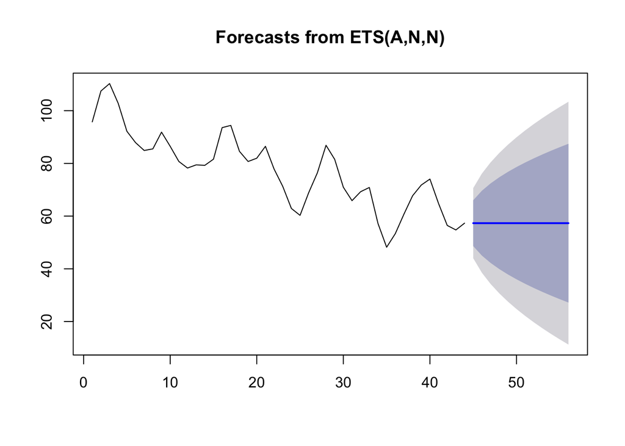

```r
fitwma = WMA(train_TS, n=2, 1:2)
predwma = forecast(fitwma[2:length(fitwma)], h=12)
plot(predwma)
```

### Find error for WMA on both Test and Train data

```r
wmaTrainError = regr.eval(train_TS[2:length(train_TS)],
                          fitwma[2:length(train_TS)])
wmaTestError = regr.eval(test$MeanPrice, predwma$mean)
wmaTrainError
```

```
##        mae        mse       rmse       mape
## 2.27629241 8.00836472 2.82990543 0.03076148
```

```r
wmaTestError
```

```
##        mae        mse       rmse       mape
##  8.3471731 93.1249224  9.6501255  0.1553324
```

### Exponential Moving Averages

```r
fitEma = EMA(train_TS, n=2)
predema = forecast(fitEma, h=12)
```

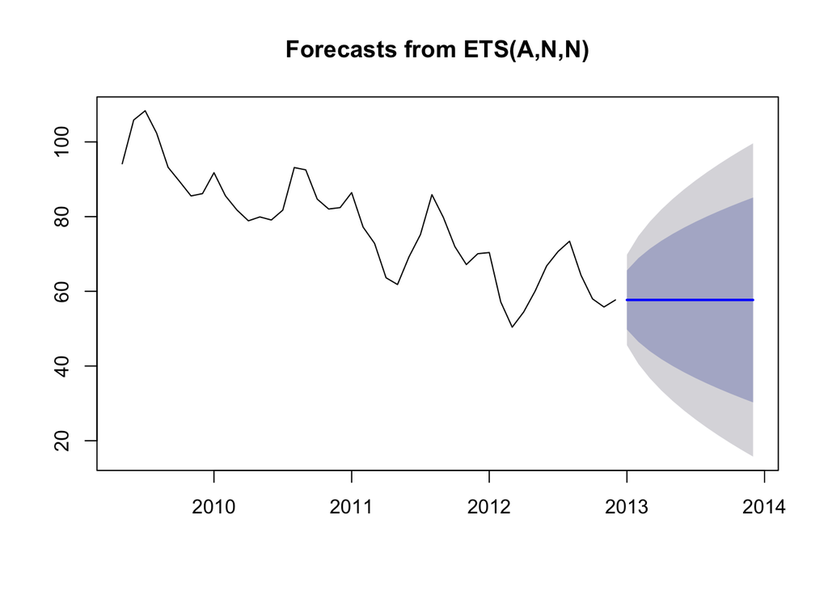

```r
plot(predema)
```

### Find error for EMA on both Test and Train data

```r
emaTrainError = regr.eval(train_TS[2:length(train_TS)], fitEma[2:length(train_TS)])
emaTestError = regr.eval(test$MeanPrice, predema$mean)
emaTrainError
```

```
##        mae        mse       rmse       mape
## 2.61643350 9.63456879 3.10396018 0.03564705
```

```r
emaTestError
```

```
##        mae        mse       rmse       mape
##  8.4077278 93.9549518  9.6930363  0.1573733
```

## Regression on time

- As trend is also present Regression on time will also work.

### Simple Linear Regression

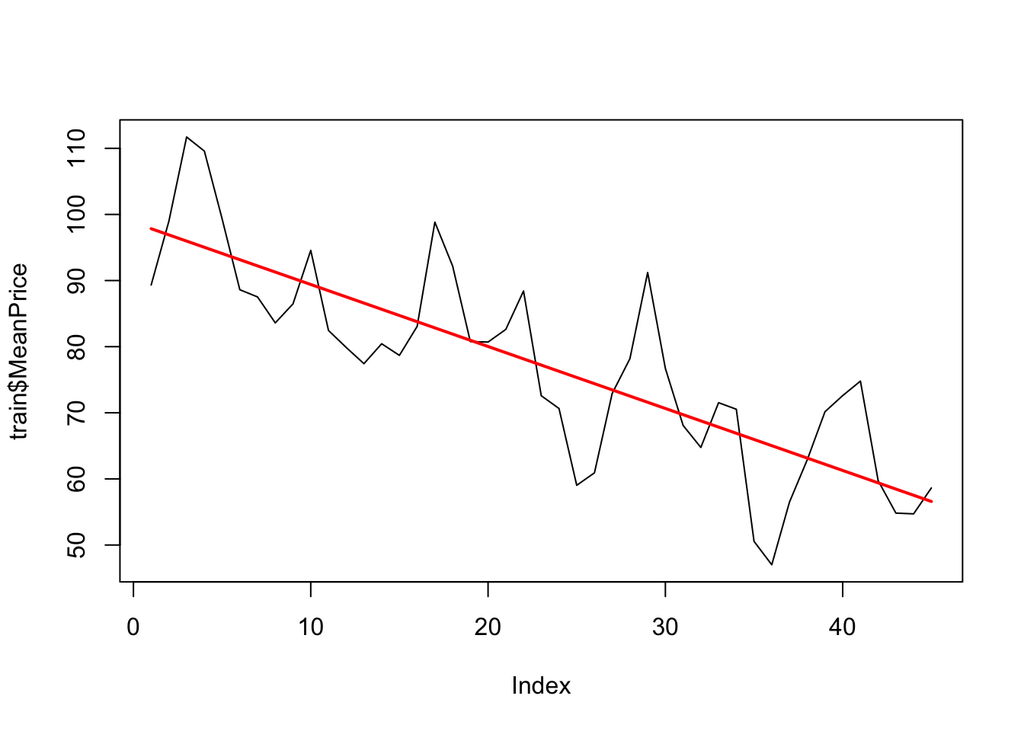

```r
## Simple linear regression
lm1 <- lm(MeanPrice~Time, data = train)

pred_Train = predict(lm1)
pred_Test = predict(lm1, test)

plot(train$MeanPrice, type="l")
points(train$Time, pred_Train, type="l", col="red", lwd=2)
```

### Find error for lm1 on both Test and Train data

```r
lm1TrainError = regr.eval(train$MeanPrice, pred_Train)
lm1TestError = regr.eval(test$MeanPrice,pred_Test)
lm1TrainError
```

```
##         mae         mse        rmse        mape
##  7.03431426 77.24627672  8.78898610  0.09489479
```

```r
lm1TestError
```

```
##         mae         mse        rmse        mape
##   9.1439128 131.9396415  11.4864982   0.1527641
```

### Linear Regression (Quadratic)

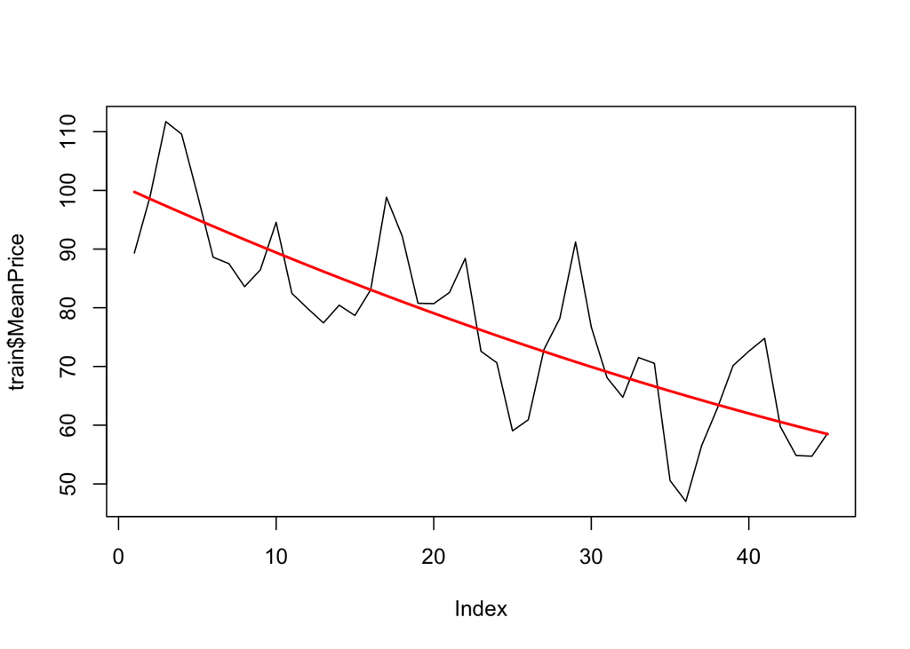

```r
lm2 <- lm(MeanPrice~poly(Time, 2, raw=TRUE), data = train)

pred_Train = predict(lm2)
pred_Test = predict(lm2, test)

plot(train$MeanPrice, type="l")
points(train$Time, pred_Train, type="l", col="red", lwd=2)
```

### Find error for lm2 on both Test and Train data

```r
lm2TrainError = regr.eval(train$MeanPrice, pred_Train)
lm2TestError = regr.eval(test$MeanPrice, pred_Test)
lm2TrainError
```

```
##         mae         mse        rmse        mape
##  7.00157265 76.42743353  8.74227851  0.09451255
```

```r
lm2TestError
```

```
##        mae        mse       rmse       mape
##  7.9656467 97.2905284  9.8635961  0.1398358
```

### Seasonal Linear Regression Model using dummies

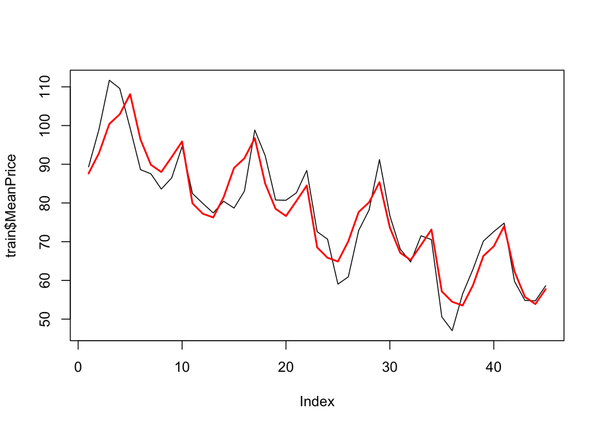

```r
slm1 <- lm(MeanPrice~., data=train)

pred_Train = predict(slm1)
pred_Test = predict(slm1, test)

plot(train$MeanPrice, type="l")
points(train$Time, pred_Train, type="l", col="red", lwd=2)
```

### Find error for slm1 on both Test and Train data

```r
slm1TrainError = regr.eval(train$MeanPrice, pred_Train)
slm1TestError = regr.eval(test$MeanPrice, pred_Test)
slm1TrainError
```

```
##         mae         mse        rmse        mape
##  4.10150034 24.54719694  4.95451279  0.05388787
```

```r
slm1TestError
```

```
##        mae        mse       rmse       mape
##  6.8731154 66.1982183  8.1362288  0.1169832
```

## ARIMA Models

### Manual ARIMA Model

- The order of the model p is determined based on the number beyond which PACF terms are zero.
- The number of terms, q, is determined from the ACF plot. Its the m aximum lag beyond which the ACF is 0

### ACF and PACF Plots

```r
par(mfrow=c(1,1))
plot(diff(train_TS, lag=1), type="l")
```

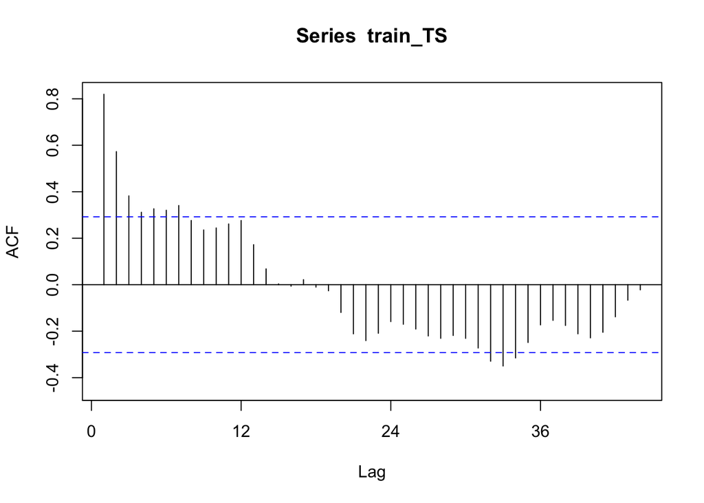

```r
Acf(train_TS,lag=44)
```

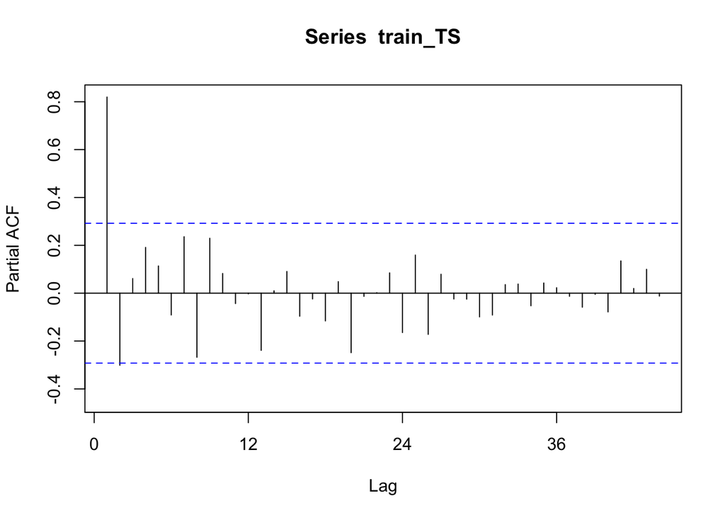

```r
Pacf(train_TS,lag=44)
```

### Stationarize by differencing

- d is the number of non-seasonal differences
- D is the number of seasonal differences

```r
ndiffs(train_TS)
```

```
## [1] 1
```

```r
nsdiffs(train_TS)
```

```
## [1] 1
```

- Lets do a seasonal differencing first and then plot Acf and Pacf

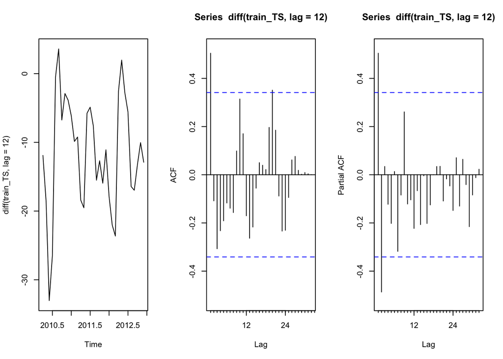

```r
par(mfrow=c(1,3))

plot(diff(train_TS, lag=12),type="l")

Acf(diff(train_TS,lag = 12),lag=40)
Pacf(diff(train_TS,lag = 12),lag=40)
```

- Lets do a seasonal differencing first and then plot Acf and Pacf

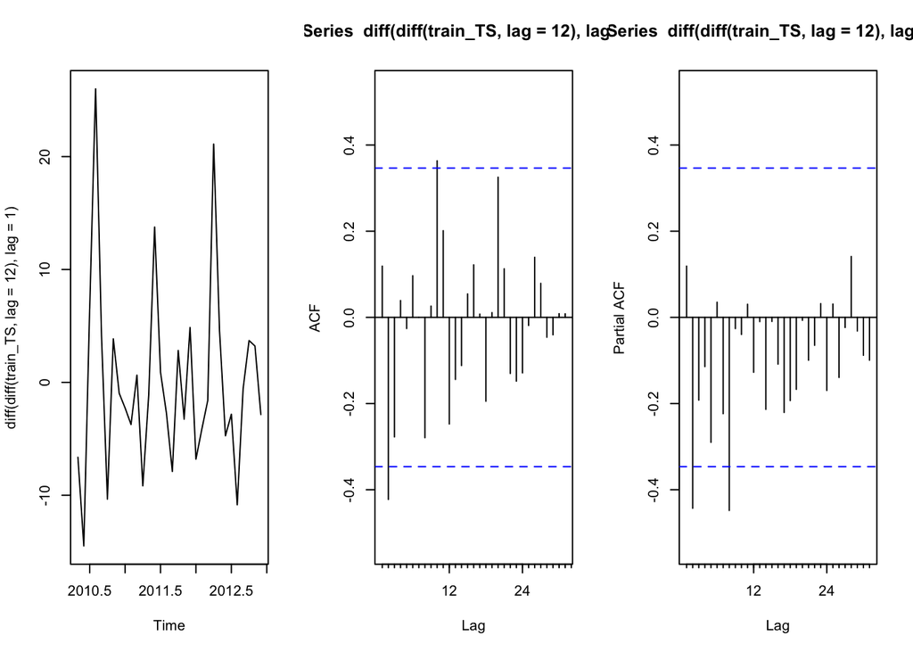

```r
par(mfrow=c(1,3))

plot(diff(diff(train_TS, lag=12), lag=1),type="l")

Acf(diff(diff(train_TS, lag=12), lag=1),lag=40)
Pacf(diff(diff(train_TS, lag=12), lag=1),lag=40)
```

- ARIMA model ARIMA(2,1,2)(0,1,0)

```r
ARIMA_1 = Arima(train_TS, c(2,1,2), c(0,1,0))
summary(ARIMA_1)
```

```
## Series: train_TS
## ARIMA(2,1,2)(0,1,0)[12]
##
## Coefficients:
##          ar1      ar2      ma1      ma2
##       0.6589  -0.4058  -0.8790  -0.1210
## s.e.  0.3814   0.2585   0.4502   0.4411
##
## sigma^2 estimated as 45.5:  log likelihood=-106.08
## AIC=222.16   AICc=224.47   BIC=229.49
##
## Training set error measures:
##                     ME    RMSE      MAE       MPE     MAPE      MASE
## Training set 0.3516308 5.32058 3.446217 0.1395941 4.895328 0.2914243
##                    ACF1
## Training set 0.01384672
```

### Check the acf and pacf plots

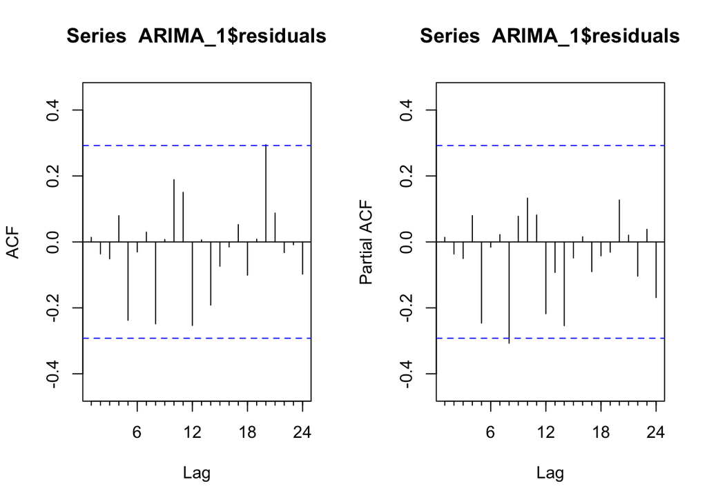

```r
par(mfrow = c(1,2))
Acf(ARIMA_1$residuals)
Pacf(ARIMA_1$residuals)
```

### Plots the residuals

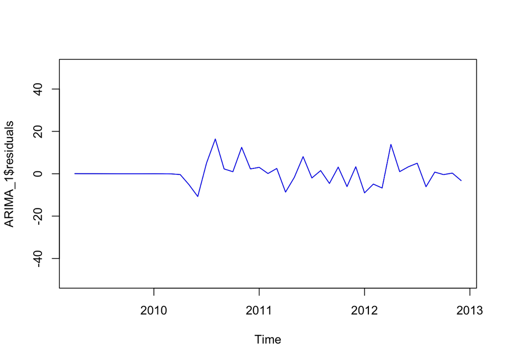

```r
plot(ARIMA_1$residuals,ylim=c(-50,50))
points(ARIMA_1$residuals, type = 'l', col = "blue")
```

### Box-Ljung Test

- Null Hypothesis : Error are not correlated
- Alternative Hypothesis: Error are correlated

```r
Box.test(ARIMA_1$residuals, type="Ljung-Box", lag = 24)
```

```
##
##  Box-Ljung test
##
## data:  ARIMA_1$residuals
## X-squared = 27.821, df = 24, p-value = 0.2677
```

```r
# No significant spikes
```

## Predictions

### Prediction on the Train

```r
pred_Train = fitted(ARIMA_1)
pred_Train
```

```
##            Jan       Feb       Mar       Apr       May       Jun       Jul
## 2009                                89.28030  98.95172 111.68258 109.55896
## 2010  94.55729  82.46014  79.94629  77.79323  85.58278  89.42720  78.02184
## 2011  85.39389  72.47120  68.14879  67.68399  62.60860  64.84479  80.16920
## 2012  79.55127  55.43289  53.73744  42.63022  61.89098  66.85123  67.61846
##            Aug       Sep       Oct       Nov       Dec
## 2009  99.33892  88.61861  87.52620  83.60228  86.48052
## 2010  82.42838  89.92391  79.81077  68.23277  80.32662
## 2011  89.72661  81.27448  64.95857  70.80051  68.22652
## 2012  80.91522  58.96085  55.21944  54.40762  61.83493
```

```r
pred_Test = forecast(ARIMA_1, h = 12)
```

### Find error for Arima_1 on both Test and Train data

```r
regr.eval(train$MeanPrice, pred_Train)
```

```
##         mae         mse        rmse        mape
##  3.44621696 28.30856658  5.32057953  0.04895328
```

```r
regr.eval(test$MeanPrice, data.frame(pred_Test)$Point.Forecast)
```

```
##        mae        mse       rmse       mape
##  7.1743428 80.8278252  8.9904296  0.1241053
```

### Auto Arima

```r
ARIMA_auto = auto.arima(train_TS)
summary(ARIMA_auto)
```

```
## Series: train_TS
## ARIMA(2,0,0)(1,1,0)[12] with drift
##
## Coefficients:
##          ar1      ar2     sar1    drift
##       0.8099  -0.5223  -0.5107  -0.9514
## s.e.  0.1464   0.1506   0.1861   0.0856
##
## sigma^2 estimated as 33.57:  log likelihood=-104.95
## AIC=219.9   AICc=222.12   BIC=227.38
##
## Training set error measures:
##                      ME     RMSE     MAE        MPE     MAPE      MASE
## Training set 0.04629562 4.651219 3.20363 -0.2132761 4.536596 0.2709103
##                     ACF1
## Training set 0.004261622
```

### Forecast on autoARIMA model

```r
pred_Train = fitted(ARIMA_auto)
pred_Train
```

```
##            Jan       Feb       Mar       Apr       May       Jun       Jul
## 2009                                89.24159  98.88137 111.59877 109.46661
## 2010  94.45754  82.35958  79.78935  77.73186  85.51595  92.51849  84.11961
## 2011  84.89693  70.74730  66.87993  67.14723  65.43350  72.56656  81.13011
## 2012  77.79436  55.13288  52.13292  47.31465  63.75157  63.32325  67.94782
##            Aug       Sep       Oct       Nov       Dec
## 2009  99.24235  88.52068  87.42792  83.50379  86.38174
## 2010  88.53575  93.63934  82.49020  70.18774  80.04975
## 2011  83.70869  81.32955  64.97488  63.96800  66.61289
## 2012  79.25818  60.09992  52.73253  57.62292  60.48256
```

```r
pred_Test = forecast(ARIMA_auto, h=12)
pred_Test
```

```
##          Point Forecast    Lo 80    Hi 80    Lo 95    Hi 95
## Jan 2013       61.85260 54.42737 69.27784 50.49669 73.20852
## Feb 2013       44.77834 35.22312 54.33357 30.16489 59.39179
## Mar 2013       42.31469 32.70804 51.92134 27.62259 57.00679
## Apr 2013       40.81755 30.93068 50.70441 25.69689 55.93820
## May 2013       44.60396 34.42725 54.78066 29.04003 60.16788
## Jun 2013       54.15359 43.95057 64.35662 38.54941 69.75778
## Jul 2013       58.08495 47.86018 68.30971 42.44752 73.72237
## Aug 2013       65.92300 55.65674 76.18927 50.22210 81.62391
## Sep 2013       51.20615 40.93213 61.48016 35.49339 66.91890
## Oct 2013       44.40190 34.12665 54.67714 28.68727 60.11652
## Nov 2013       42.60637 32.32561 52.88713 26.88331 58.32944
## Dec 2013       47.95260 37.67009 58.23512 32.22685 63.67835
```

### Find error for Arima_1 on both Test and Train data

```r
regr.eval(train$MeanPrice, pred_Train)
```

```
##         mae         mse        rmse        mape
##  3.20362991 21.63383608  4.65121877  0.04536596
```

```r
regr.eval(test$MeanPrice, data.frame(pred_Test)$Point.Forecast)
```

```
##        mae        mse       rmse       mape
##  6.9284070 67.7724304  8.2324013  0.1195423
```

- Comparing the AIC Auto Arima is giving good results for the product item considered. Comparing MAPE, Auto ARIMA gives slightly better results